# PEC_4

#### Sex

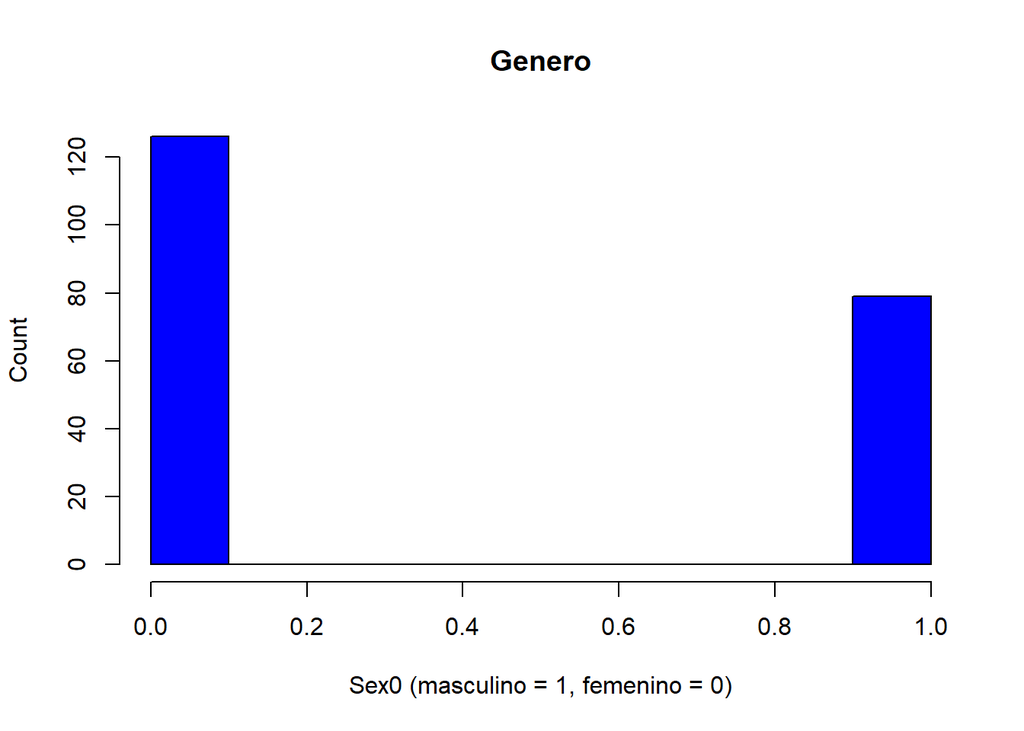

```r
hist(dataset$sex,
main = "Genero",
xlab = "Sex0 (masculino = 1, femenino = 0)",
ylab = "Count",
col = "blue")
```

#### Age

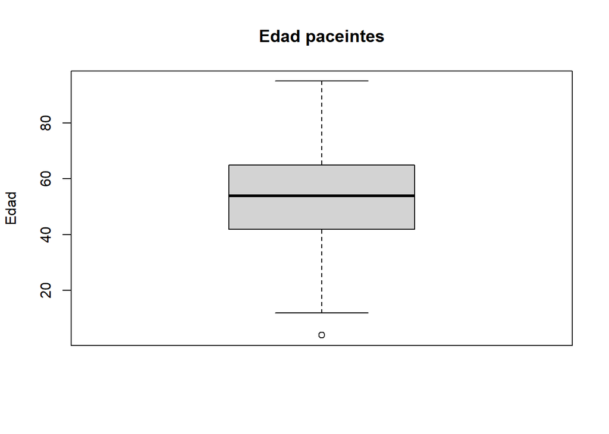

```r
boxplot(dataset$age,
        main = "Edad paceintes",
        ylab = "Edad")
```

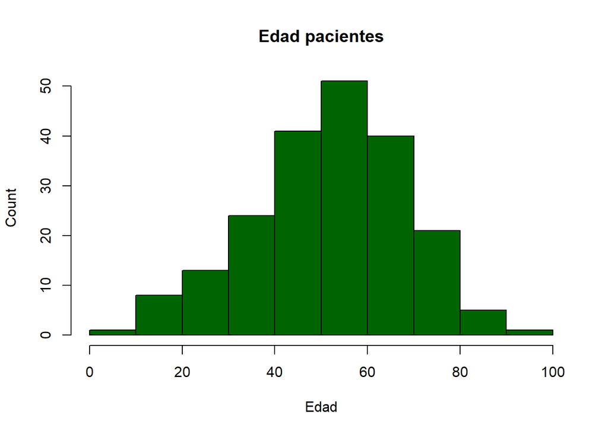

```r
hist(dataset$age,
main = "Edad pacientes",
xlab = "Edad",
ylab = "Count",
col = "darkgreen")
```

#### Year

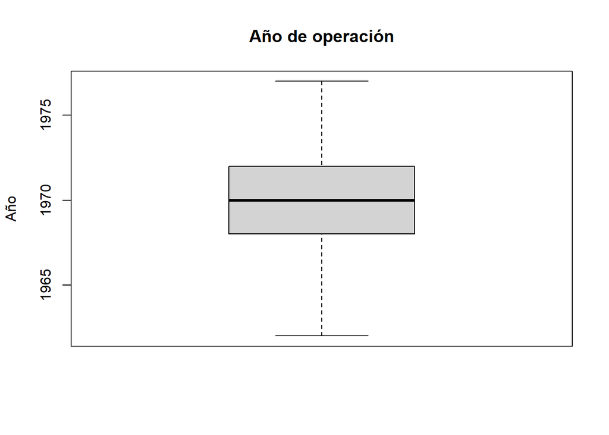

```r
boxplot(dataset$year,
        main = "Año de operación",
        ylab ="Año")
```

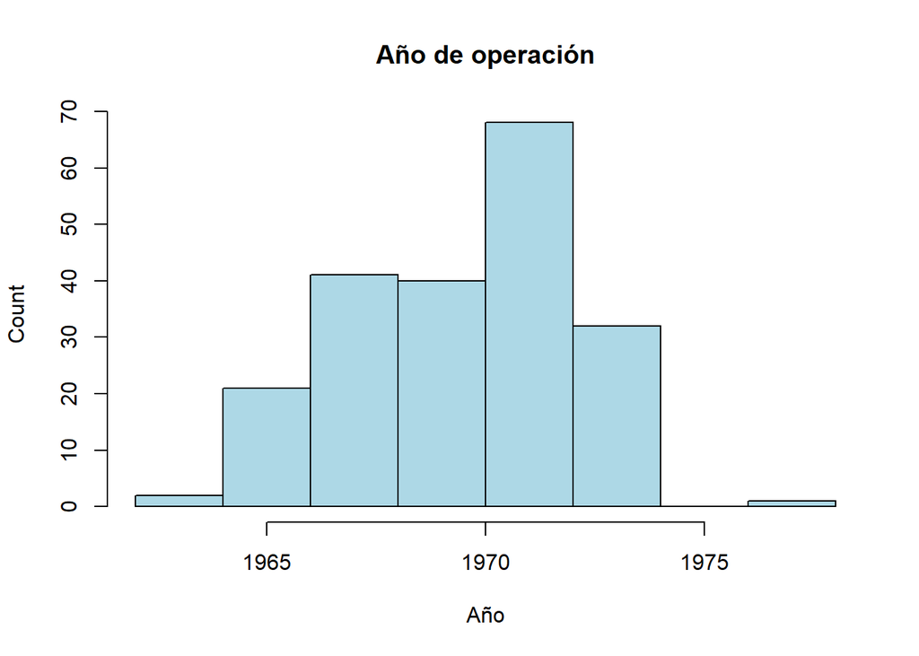

```r
hist(dataset$year,
main = "Año de operación",
xlab = "Año",
ylab = "Count",
col = "lightblue")
```

#### Thickness

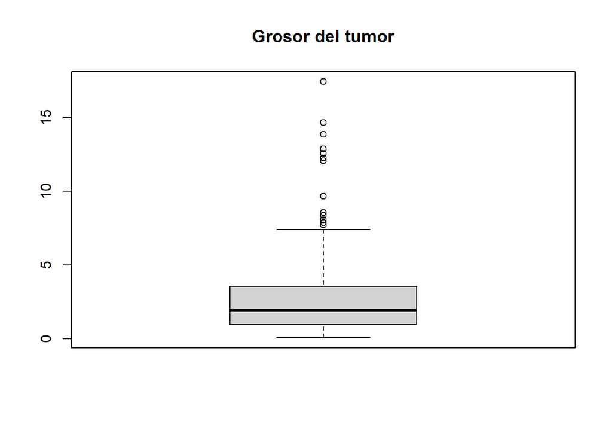

```r
boxplot(dataset$thickness,
        main="Grosor del tumor",
        ylabel="Grosor (mm)")
```

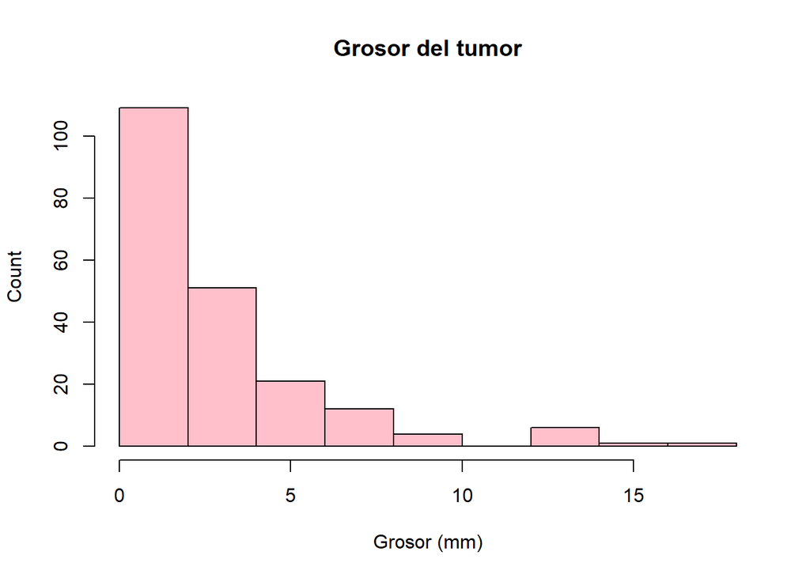

```r
hist(dataset$thickness,
main = "Grosor del tumor",
xlab = "Grosor (mm)",
ylab = "Count",
col = "pink")
```

#### Ulcer

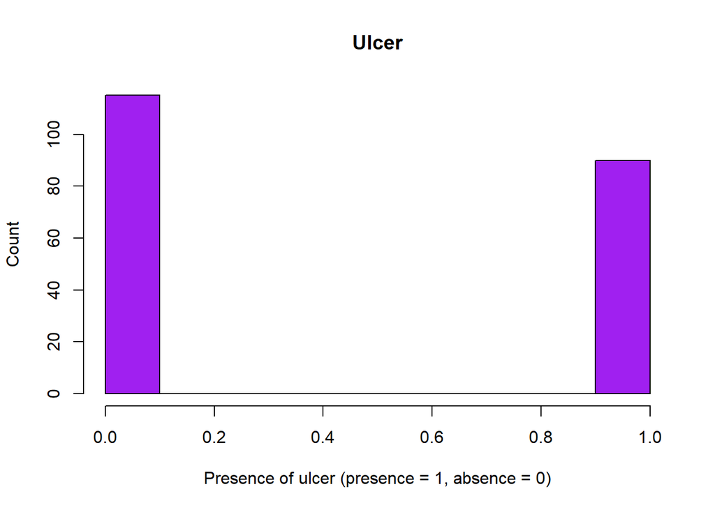

```r
hist(dataset$ulcer,
main = "Ulcer",
xlab = "Presence of ulcer (presence = 1, absence = 0)",
ylab = "Count",
col = "purple")
```

### 5. 3 enunciados cuestión de probabilidad, 1 enunciado modelo de simulación

#### 1. ¿Cuál es la probabilidad de tener un melanoma de grosor superior a 5mm?

```r
library(dplyr)
```

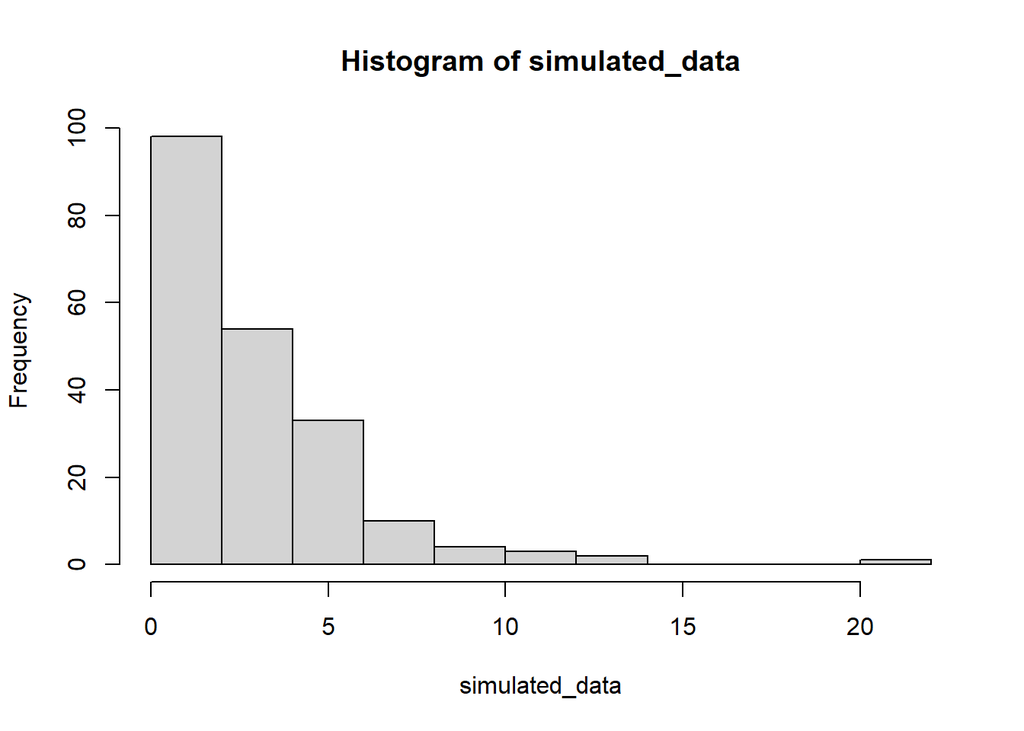

```r
set.seed(123)

# Simulamos una distribución exponencial negativa basada en nuestra media muestral
simulated_data <- rexp(length(dataset$thickness), rate = 1/mean(dataset$thickness))

# Mostramos los datos simulados y vemos que se asemejan a la distribución real
hist(simulated_data)
```

```r
p_grosor_mayor_5 <- 1 - pexp(5, rate = 1/mean(simulated_data))


cat("La probabilidad de tener un melanoma de un grosor mayor a 5mm es de:",p_grosor_mayor_5)
```

```
## La probabilidad de tener un melanoma de un grosor mayor a 5mm es de: 0.1818568
```

#### 2. ¿Cuál es la probabilidad de sobrevivir con un melanoma con presencia de úlcera?

```r
num_t <- nrow(dataset)
sob_t <- nrow(dataset[dataset$status ==2, ])
ulc_p <- nrow(dataset[dataset$ulcer==1, ])

prob_sob <- (ulc_p/num_t)*(sob_t/num_t)
cat("La probabilidad de sobribir a un melanoma con úlcera es de",prob_sob)
```

```
## La probabilidad de sobribir a un melanoma con úlcera es de 0.286972
```

#### 3. ¿Influye el género en la probabilidad de muerte por melanoma?

```r
male_data <- dataset %>% filter(sex == 1)
female_data <- dataset %>% filter(sex == 0)

num_t <- nrow(dataset)
num_m <- nrow(male_data)
num_f <- nrow(female_data)

muertes_t <- nrow(dataset[dataset$status ==1, ])
muertes_m <- nrow(male_data[male_data$status == 1, ])
muertes_f <- nrow(female_data[female_data$status == 1, ])

prob_morir_siendo_hombre <- muertes_m/num_m
prob_morir_siendo_mujer <- muertes_f/num_f

prob_m <- (num_m/num_t)*prob_morir_siendo_hombre
prob_f <- (num_f/num_t)*prob_morir_siendo_mujer

cat("La probabilidad de morir de melanoma siendo hombre es de:",prob_m, "y la probabilidad de morir de melanoma siendo mujer",prob_f)
```

```
## La probabilidad de morir de melanoma siendo hombre es de: 0.1414634 y la probabilidad de morir de melanoma siendo mujer 0.1365854
```

Aunque exista una leve diferencia entre la probabilidad de morir en los dos géneros, no podemos afirmar que sea significativa, y por lo tanto, este calculo no seria suficiente para determinar con certeza que el género influye en la probabilidad de muerte por melanoma

#### 4. Haz 3 simulaciones para diferentes tamaños muestrales (n) de la distribución de Edad de los pacientes de melanoma y a partir de aquí calcula la probabilidad de tener melanoma con una edad inferior a 40 años

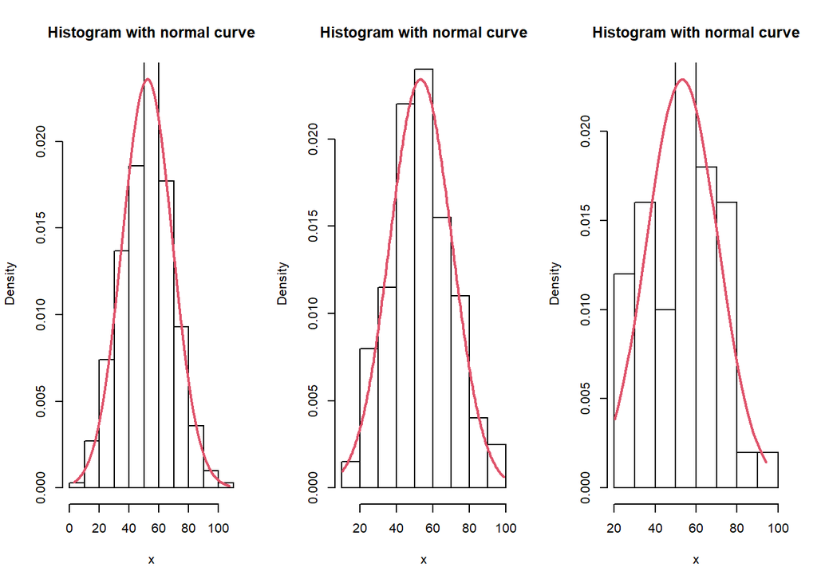

```r
set.seed(154)
random_normal <- function(n){
  set.seed(154)

  x <- rnorm(n, mean(dataset$age), sd(dataset$age))

  x2 <- seq(min(x), max(x), length = n)

  # Corva normal
  fun <- dnorm(x2, mean = mean(x), sd = sd(x))

  # Histograma
  hist(x, prob = TRUE, col = "white",
       ylim = c(0, max(fun)),
       main = "Histogram with normal curve")
  lines(x2, fun, col = 2, lwd = 2)
}


par(mfrow = c(1, 3))
random_normal(1000)
random_normal(200)
random_normal(50)
```

```r
edades <- rnorm(200, mean = mean(dataset$age), sd = sd(dataset$age))# Escojemos la distribución con 200 muestras

# Contar la proporción de edades menores a 40
probabilidad_menos_40 <- sum(edades < 40) / 200

cat("La probabilidad de tener melanoma con una edad inferior a 40 años es de:",probabilidad_menos_40)
```

```
## La probabilidad de tener melanoma con una edad inferior a 40 años es de: 0.195
```

Observamos que la simulación para n=200 es la más parecida visualmente a la distribución real de nuestra muestra, ya que el número de filas en nuestro dataset también es de 200 aproximadamente.Es por eso que escojemos esta distribución para realizar el cálculo.

### 6. Regressión múltiple para predecir el grosor del melanoma

```r
#Definimos i entrenamos el modelo regressión lineal simple
model <- lm(thickness ~ time, data = dataset)


summary(model)
```

```
##
## Call:
## lm(formula = thickness ~ time, data = dataset)
##
## Residuals:
##     Min      1Q  Median      3Q     Max
## -3.8761 -1.8576 -0.8658  0.8727 13.9781
##
## Coefficients:
##               Estimate Std. Error t value Pr(>|t|)
## (Intercept)  4.2565053  0.4365428   9.750  < 2e-16 ***
## time        -0.0006209  0.0001799  -3.451 0.000679 ***
## ---
## Signif. codes:  0 '***' 0.001 '**' 0.01 '*' 0.05 '.' 0.1 ' ' 1
##
## Residual standard error: 2.883 on 203 degrees of freedom
## Multiple R-squared:  0.05542,    Adjusted R-squared:  0.05076
## F-statistic: 11.91 on 1 and 203 DF,  p-value: 0.0006793
```

La R-squared ajustada es de 0.05, esto significa que el tiempo de supervivencia no es capaz de predecir el grosor del melanoma. Para poder hacer esta predicción con mayor certeza tendremos que recurrir a un modelo de regressión múltiple que tenga en cuenta el resto de las variables:

```r
#Definimos y entrenamos el modelo de regresión lineal múltiple
modelo_regression = lm(formula = thickness ~ time + status + sex + age + year + ulcer,data = dataset)

summary(modelo_regression)
```

```
##
## Call:
## lm(formula = thickness ~ time + status + sex + age + year + ulcer,
##     data = dataset)
##
## Residuals:
##     Min      1Q  Median      3Q     Max
## -4.3912 -1.3032 -0.3632  0.4862 12.8118
##
## Coefficients:
##               Estimate Std. Error t value Pr(>|t|)
## (Intercept)  5.711e+02  1.697e+02   3.366 0.000915 ***
## time        -5.558e-04  2.177e-04  -2.553 0.011442 *
## status      -5.035e-02  3.739e-01  -0.135 0.893002
## sex          5.355e-01  3.764e-01   1.423 0.156419
## age          2.655e-02  1.142e-02   2.324 0.021162 *
## year        -2.890e-01  8.609e-02  -3.357 0.000944 ***
## ulcer        1.928e+00  3.896e-01   4.949 1.59e-06 ***
## ---
## Signif. codes:  0 '***' 0.001 '**' 0.01 '*' 0.05 '.' 0.1 ' ' 1
##
## Residual standard error: 2.565 on 198 degrees of freedom
## Multiple R-squared:  0.2708, Adjusted R-squared:  0.2487
## F-statistic: 12.25 on 6 and 198 DF,  p-value: 1.034e-11
```

Podemos observar que los parámetros más importantes a la hora de predecir el grosor de un tumor es la presencia de ulcera, el año de la operación y el tiempo de supervivencia.

La Adjusted R-squared es de 0.2487, esto indica un ajuste limitado y una predicción erronea del grosor del melanoma en la mayoría de situaciones.

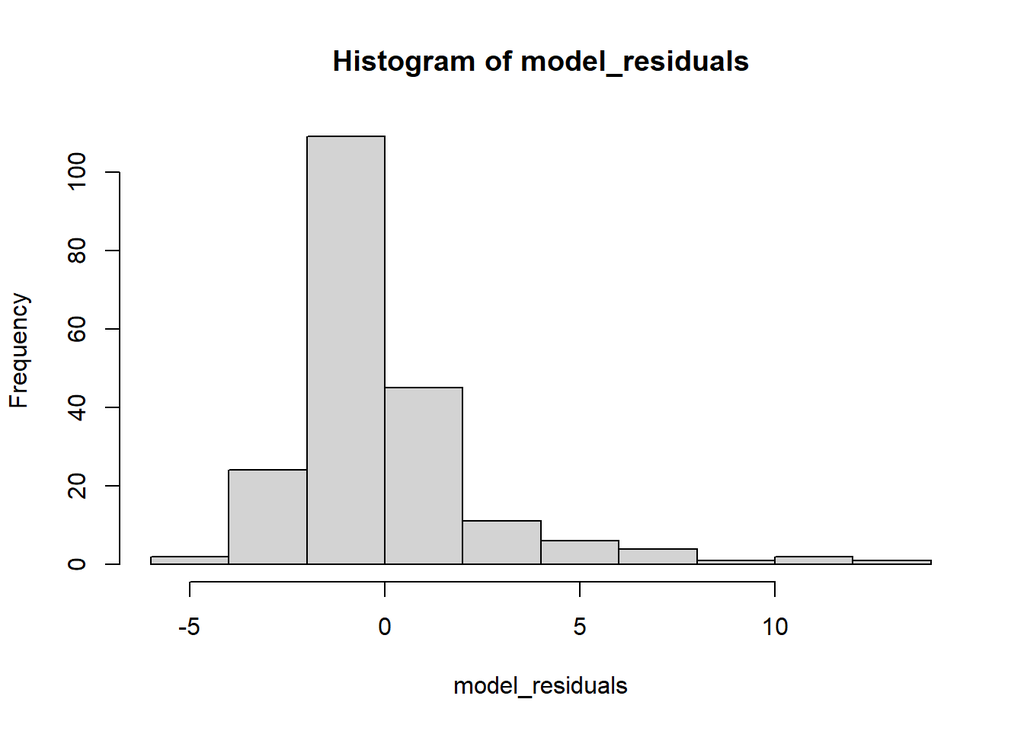

```r
# Obtenim els residuals del model
model_residuals = modelo_regression$residuals

# Fem un histograma dels resiudals
hist(model_residuals)
```

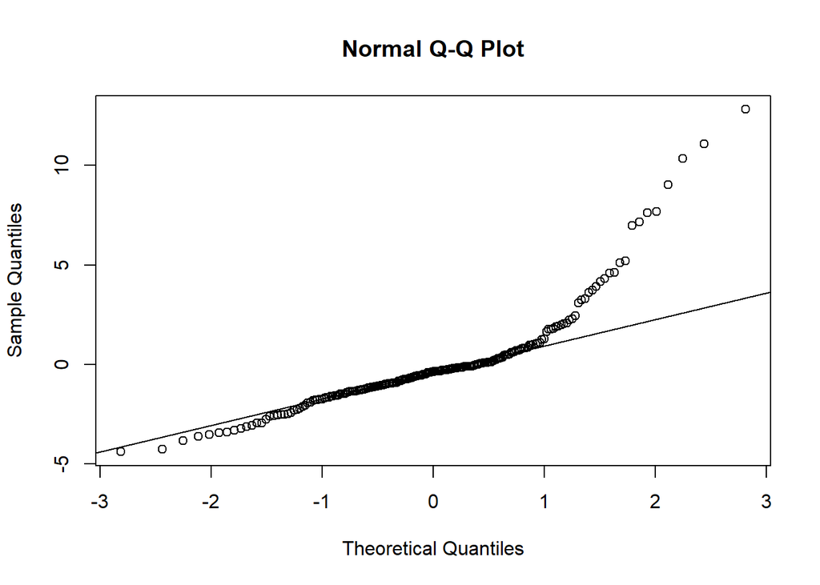

```r
# Printem qqplot dels residuals
qqnorm(model_residuals)
qqline(model_residuals)
```

Podemos asumir que los residuos del modelo no siguen una distribución normal debido a que los quantiles de los residuos no se sobreponen de forma adecuada a la recta patrón.Y el histograma de los residuos del modelo no se asemeja visualmente a una distribución normal.

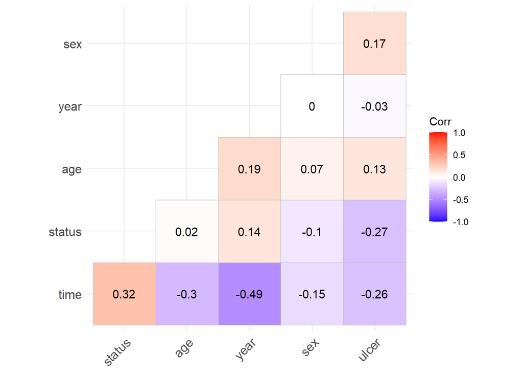

```r
library(ggcorrplot)
# quitamos thickness del dataset
reduced_data <- subset(dataset, select = -thickness)

# Calculamos correlaciones
corr_matrix = round(cor(reduced_data), 2)

# printamos resultado
ggcorrplot(corr_matrix, hc.order = TRUE, type = "lower",
          lab = TRUE)
```

Podemos ver correlación positiva entre el tiempo y el status (0.32), ya que cuanto mayor es el tiempo de supervivencia, más probable es que el status sea 2, que indica la supervivencia del paciente.